# Wizualuizacja danych w języku Python Matplotlib cz. 1

### Zadanie 1.

Korzystając z danych znajdujących się w pliku `dane.csv` wczytaj dane a nastepnie stwórz nową kolumnę `Sprzedaz calkowita`. Następnie utworz nową ramkę danych (`sprzedaz`) bez kolumn sprzedaży poszczególnych produktów.

Wyświelt sprzedaż całkowitą za pomocą wykresu liniowego.

```python
dane = pd.read_csv('dane.csv', sep = ';', decimal = ',', index_col=0)
dane['Sprzedaz całkowita'] = dane['prodA'] + dane['prodB']
sprzedaz = dane.drop(['prodA', 'prodB'], axis = 1)
```

```python
sprzedaz['mies_cat'] = pd.Categorical(sprzedaz.Miesiac,
                      categories=["styczen","luty","marzec"],
                      ordered=True)
```

```python
sprzedaz.sort_values(['mies_cat', 'dzien'], inplace = True, ignore_index = True)
```

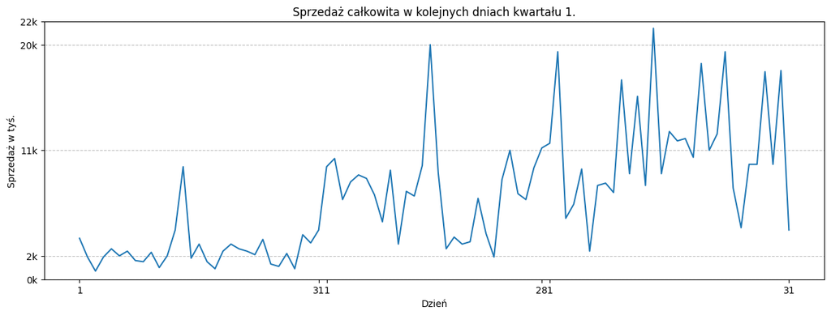

### Zadanie 2.

Z ramki `sprzedaz` usuń dane z lutego.

### a)

A następnie przygotuj zestawienie:

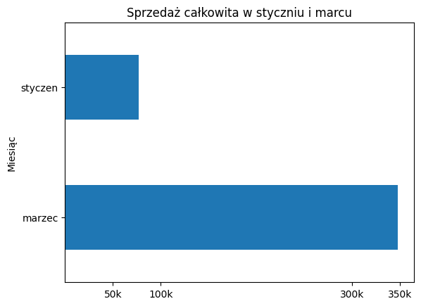

### b)

A następnie przygotuj zestawienie:

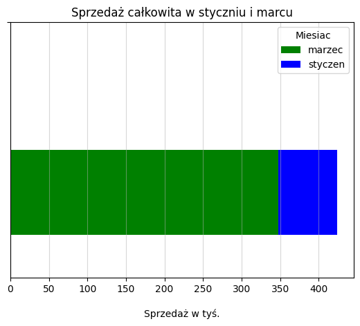

### Zadanie 3.

Korzystając z danych znajdujących się w pliku `dane.csv` wczytaj dane a nastepnie dla sprzedaży z marca wyświetl kolumny sprzedaży produktów `A` i `B`, wiersze uporządkuj malejąco dla produktu `A`. Wyniki przedstaw na wykresie punktowym.

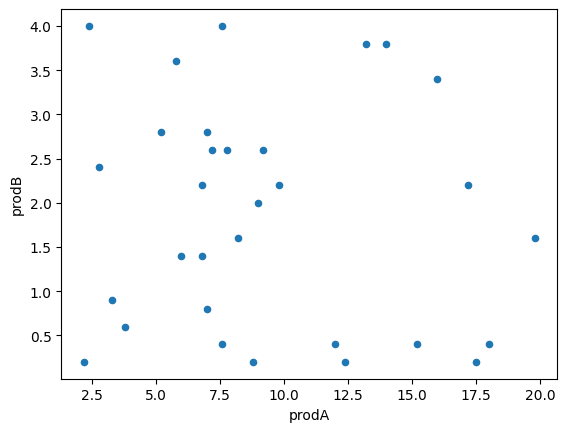

### Zadanie 4.

### a)

Korzystając z danych znajdujących się w pliku `dane.csv` wczytaj dane a nastepnie wyświetl informacje o miesiącu i sprzedaży produktu `A` większej od średniej sprzedaży tego produktu wyniki uporządkuj po miesiącu zachowując porządek zgodny z kolejnością miesięcy a w obrębie miesiąca po wielkości sprzedaży.

### b)

Zlicz ile było dni ze sprzedażą powyżej średniej, wyniki przedstaw na wykresie.

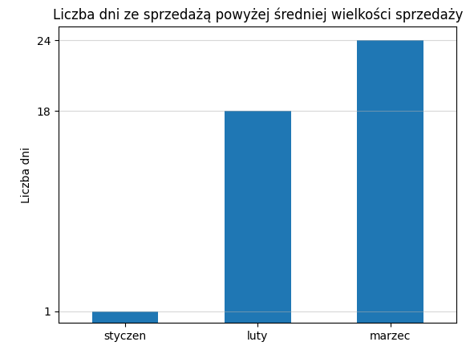

### Zadanie 5.

Korzystając z danych znajdujących się w pliku `dane.csv` wczytaj dane a nastepnie wyznacz sumaryczną sprzedaż dla produktów w każdym miesiącu, wyniki przedstaw na wykresie.

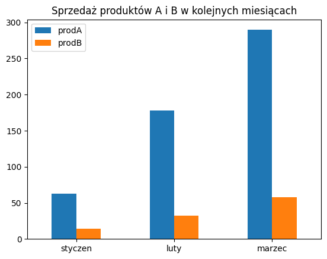

### Zadanie 6.

Korzystając z danych znajdujących się w pliku `dane.csv` wczytaj dane a nastepnie przygotuj wykres prezentujący sprzedaż produktu B w kolejnych dniach kwartału 1. z oznaczeniem dni w których sprzedaż była maksymalna.

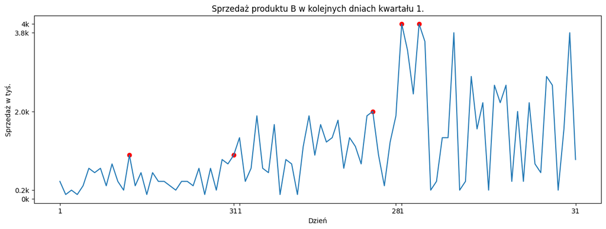